# Movement Analisys - Machine Learning Project

# Summary

Using devices such as Jawbone Up, Nike FuelBand, and Fitbit it is now possible to collect a large amount of data about personal activity relatively inexpensively. These type of devices are part of the quantified self movement - a group of enthusiasts who take measurements about themselves regularly to improve their health, to find patterns in their behavior, or because they are tech geeks. One thing that people regularly do is quantify how much of a particular activity they do, but they rarely quantify how well they do it. In this project, your goal will be to use data from accelerometers on the belt, forearm, arm, and dumbell of 6 participants. They were asked to perform barbell lifts correctly and incorrectly in 5 different ways. More information is available from the website here: http://groupware.les.inf.puc-rio.br/har (see the section on the Weight Lifting Exercise Dataset).

### Loading and Cleaning the Data

As a cleaning procedure, we’ll remove innecesary columns that wont add accuracy to the model. Also, we will strip any column/variable where the number of NAs exceeds 50% of the data of that column

```r
library(caret)
library(dplyr)
library(rpart)
library(kernlab)
library(reshape2)
library(knitr)
library(doParallel)
library(ggplot2)
library(ggthemes)

set.seed(1234556) #Give it to me baby, aha, aha!
strings.na <- c("NA","#DIV/0!","")
training = read.csv("pml-training.csv", na.strings = strings.na)
testing = read.csv("pml-testing.csv", na.strings = strings.na)

training = training[,!grepl("^X|new_window|timestamp|user_name", names(training))] #Removing Columns
training = training[, colSums(is.na(training)) < (nrow(training)/2)] #Remove Columns With NAs > 50%
```

### Creating Partitions

```r
inTrain = createDataPartition(y=training$classe, p=0.70, list=FALSE)
training.set = training[inTrain,]
testing.set = training[-inTrain,]
```

### Creating Parallelism and Fitting our model

Since the computing of the models are lenghty proccesses, we choose to use more than one processor.

To fit the predictive model, we are using Random Forest. This algorithm is characterized by a subset of features, selected in a random and independent manner with the same distribution for each of the trees in the forest. We’ll be using repeated cross validation, with a k-fold of 5, repeated 5 times.

For presentation purposes, the code in the chunk below wont be evaluated, but will be loaded already computed.

```r
cl <- makeCluster(4)
registerDoParallel(cl)
rF.model = train(classe ~ .,
                           data=training.set,
                           method="rf",
                           importance= TRUE,
                           trControl = trainControl(method = "repeatedcv", number = 5, repeats = 5)
                          )
stopCluster(cl)
saveRDS(rF.model, file = "rFModel.rds")
```

### Training Set

```r
rF.model = readRDS("rFModel.rds")
rF.predict.train = predict(rF.model, newdata = training.set)
rF.train.cfMatrix = confusionMatrix(data=rF.predict.train,  training.set$classe)
rF.train.cfMatrix$overall
```

```
##       Accuracy          Kappa  AccuracyLower  AccuracyUpper   AccuracyNull
##      0.9992720      0.9990793      0.9986617      0.9996509      0.2843416
## AccuracyPValue  McnemarPValue
##      0.0000000            NaN
```

### Testing Set

Next, we procced to apply our model to the testing set to evaluate our predictions

```r
rF.predict.test = predict(rF.model, newdata = testing.set)
rF.test.cfMatrix = confusionMatrix(data=rF.predict.test,  testing.set$classe)
rF.test.cfMatrix$overall
```

```
##       Accuracy          Kappa  AccuracyLower  AccuracyUpper   AccuracyNull
##      0.9996602      0.9995701      0.9987729      0.9999588      0.2844520
## AccuracyPValue  McnemarPValue
##      0.0000000            NaN
```

### Test Set - Confusion Matrix

```r
kable(rF.test.cfMatrix$table)
```

|  | A | B | C | D | E |
| --- | --- | --- | --- | --- | --- |
| A | 1674 | 0 | 0 | 0 | 0 |
| B | 0 | 1138 | 1 | 0 | 0 |
| C | 0 | 1 | 1025 | 0 | 0 |
| D | 0 | 0 | 0 | 964 | 0 |
| E | 0 | 0 | 0 | 0 | 1082 |

### Out of Sample Errors

```r
missClass = function(values, prediction) {
    sum(prediction != values)/length(values)
}
errRate = missClass(testing.set$classe, rF.predict.test)
errRate = errRate * 100
```

Our selected model has an out of sample error = 0.034 % and by consequence an accuracy of 99.966 %

### Variable Importance - TOP 20

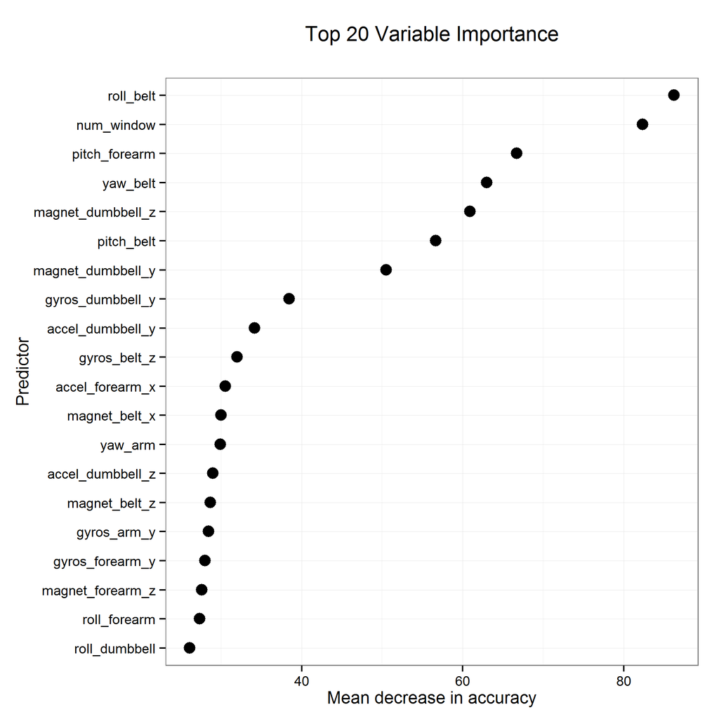

```r
#Get the variable importance from the model and melt the data frame for plotting
importance.df = as.data.frame(importance(rF.model$finalModel))
importance.df$variable = rownames(importance.df)

importance.df$variable = factor(importance.df$variable, levels = importance.df$variable[order(importance.df$MeanDecreaseAccuracy)])
importance.df = arrange(importance.df,desc(MeanDecreaseAccuracy))
importance.df = head(importance.df,n = 20)

varImp = ggplot(importance.df, aes(y=variable, x=MeanDecreaseAccuracy)) + geom_point(size = 4)
varImp = varImp + ggtitle(expression(atop("Top 20 Variable Importance"))) + labs( x="Mean decrease in accuracy", y="Predictor")
varImp = varImp + theme_bw()
varImp
```

Our most important variable is roll_belt